# Week Four

Bethany Poulin

9/28/2019

## Problem 7.1

Consider the `pigs` series — the number of pigs slaughtered in Victoria each month.

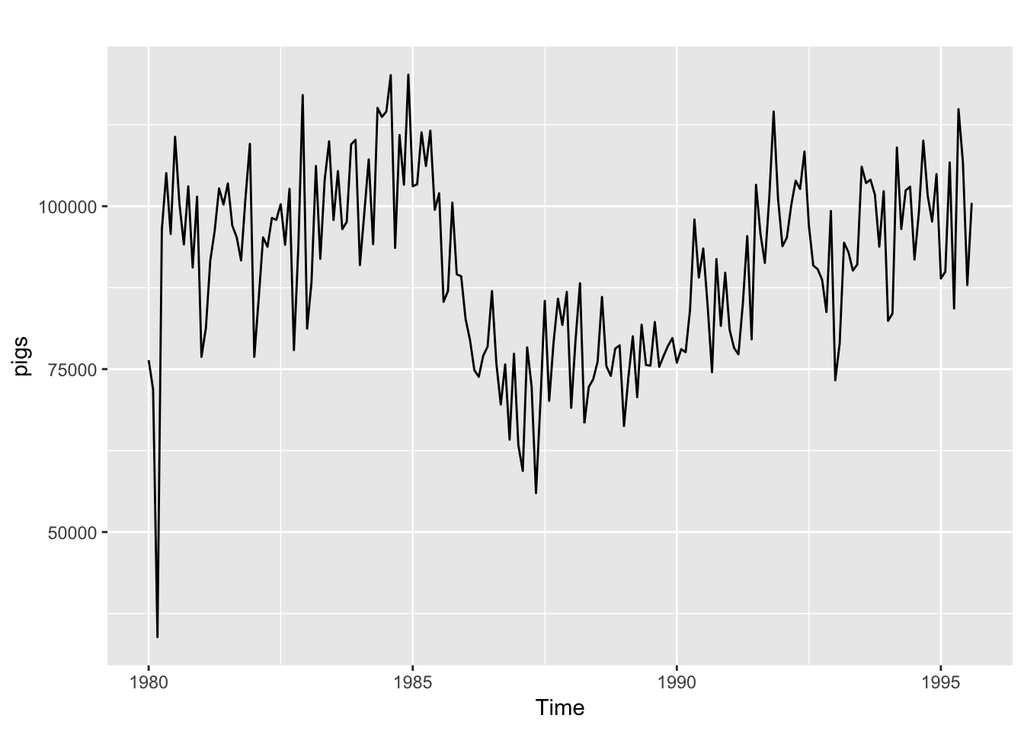

```r
require(fpp2)
autoplot(pigs)
```

```r
fit <- ses(pigs, h = 4)
fit_sum <- summary(fit)
```

```
##
## Forecast method: Simple exponential smoothing
##
## Model Information:
## Simple exponential smoothing
##
## Call:
##  ses(y = pigs, h = 4)
##
##   Smoothing parameters:
##     alpha = 0.2971
##
##   Initial states:
##     l = 77260.0561
##
##   sigma:  10308.58
##
##      AIC     AICc      BIC
## 4462.955 4463.086 4472.665
##
## Error measures:
##                    ME    RMSE      MAE       MPE     MAPE      MASE
## Training set 385.8721 10253.6 7961.383 -0.922652 9.274016 0.7966249
##                    ACF1
## Training set 0.01282239
##
## Forecasts:
##          Point Forecast    Lo 80    Hi 80    Lo 95    Hi 95
## Sep 1995       98816.41 85605.43 112027.4 78611.97 119020.8
## Oct 1995       98816.41 85034.52 112598.3 77738.83 119894.0
## Nov 1995       98816.41 84486.34 113146.5 76900.46 120732.4
## Dec 1995       98816.41 83958.37 113674.4 76092.99 121539.8
```

```r
alpha <- fit$model$par['alpha']
l <- fit$model$par['l']
forecast(fit)%>%knitr::kable()
```

|  | Point Forecast | Lo 80 | Hi 80 | Lo 95 | Hi 95 |
| --- | --- | --- | --- | --- | --- |
| Sep 1995 | 98816.41 | 85605.43 | 112027.4 | 78611.97 | 119020.8 |
| Oct 1995 | 98816.41 | 85034.52 | 112598.3 | 77738.83 | 119894.0 |
| Nov 1995 | 98816.41 | 84486.34 | 113146.5 | 76900.46 | 120732.4 |
| Dec 1995 | 98816.41 | 83958.37 | 113674.4 | 76092.99 | 121539.8 |

#### (a) Use the `ses()` function in R to find the optimal values of $\alpha$ and $l_0$ and generate forecasts for the next four months.

**alpha:** 0.297

**l:** 77260.056

#### (b) Compute a 95% prediction interval for the first forecast using $\hat y \pm1.96s$ where $s$ is the standard deviation of the residuals. Compare your interval with the interval produced by R.

```r
resid_sd <- sd(fit$model$residuals)
first_forcast <- fit_sum$`Point Forecast`[1]
upper <- first_forcast+1.96*resid_sd
lower <- first_forcast-1.96*resid_sd
# values rounded for ease of reading below
```

#### Manual Interval

**Residual Standard Deviation:**10273.693  
**Forcasted Value:** 98816.406  
**Upper 95%:** 118952.845  
**Lower 95%:** 78679.967

#### `SES()` Interval

**Upper:** 119020.8438  
**Lower:** 78611.968

The intevervals are VERY similar to the point where I would consider precision and rounding differences to be the primary drivers in the differences.

## Problem 7.3

**7.3** Modify your function from the previous exercise to return the sum of squared errors rather than the forecast of the next observation. Then use the `optim()` function to find the optimal values of $\alpha$ and $l_0$. Do you get the same values as the `ses( )` function?

#### My SSE Function

```r
my_ses <- function(pars =c(alpha, l), y){


sse=0
alpha = pars[1]
l=pars[2]
y_hat = l
#Creating a vector
s = numeric()
# Setting First Forcast
#s<-c(s, y_hat)

#Creating Forcasts
for(t in 1:length(y)){
    error = y[t]-y_hat
    y_hat <-(1-alpha)*y_hat+alpha*y[t]
    sse = sse+error^2
    #s<-c(s, y_hat)

}
 # errors <- y-s
 # squared <- errors^2
 # sse <- sum(squared)
 return(sse)
}


 optim(par=c(.5,pigs[1]), y=pigs, my_ses)
```

```
## $par
## [1]     0.2990081 76379.2653476
##
## $value
## [1] 19767049111
##
## $counts
## function gradient
##       91       NA
##
## $convergence
## [1] 0
##
## $message
## NULL
```

#### SES()` Method

```r
fit <- ses(pigs, h=1)
summary(fit)
```

```
##
## Forecast method: Simple exponential smoothing
##
## Model Information:
## Simple exponential smoothing
##
## Call:
##  ses(y = pigs, h = 1)
##
##   Smoothing parameters:
##     alpha = 0.2971
##
##   Initial states:
##     l = 77260.0561
##
##   sigma:  10308.58
##
##      AIC     AICc      BIC
## 4462.955 4463.086 4472.665
##
## Error measures:
##                    ME    RMSE      MAE       MPE     MAPE      MASE
## Training set 385.8721 10253.6 7961.383 -0.922652 9.274016 0.7966249
##                    ACF1
## Training set 0.01282239
##
## Forecasts:
##          Point Forecast    Lo 80    Hi 80    Lo 95    Hi 95
## Sep 1995       98816.41 85605.43 112027.4 78611.97 119020.8
```

The Model I built and tested using `optim()` testing on the `pigs` data I got a suggested $alpha=.299$ and a suggested $l_0=76379.27$, with `ses( )` the $alpha=.2971$ and the $l_0=77260.05$. These are close but not exact. This may be due to my use of `optim()` or it may be the chosen seed `params`